# Introdução à Visualização de Dados com o R

Capítulo 21 — *Avaliação de impacto das políticas de saúde: um guia para o SUS*

Marcelo S. Perlin · UFRGS

## A pergunta

Quarenta colunas numa planilha.  
Ou um gráfico que explica tudo em cinco segundos.

Qual dos dois muda uma decisão?

## Dado não é informação

DADO 689 mil registros

→

INFORMAÇÃO um padrão visível

→

DECISÃO onde alocar, quando agir

A visualização é a ponte mais curta entre o dado e a decisão.

## Um gráfico, o mundo inteiro entendendo

[figure not shown]

Burn Murdoch, *Financial Times* (2020) — o mesmo dado das tabelas técnicas, virou compreensão coletiva.

## O que você leva desta aula

1. Princípios que fazem uma figura justificar a sua existência
2. Componentes fixos e dinâmicos de um gráfico
3. Canais visuais — linha, ponto, barra, cor, tamanho
4. Prática — gráficos de mortalidade do SUS no R

**0:00**

Abertura

**2:00**

Objetivo

**3:00**

Conceitos

**7:00**

Aplicações

**11:00**

Prática no R

**15:00**

Fechamento

## Os quatro princípios

1 Justificar a existência Se não dá dois parágrafos sobre a figura, ela não precisa existir.

2 Direcionar a atenção Destaque o que importa: o município, o ano, o grupo fora do esperado.

3 Independência Título, subtítulo, eixos e fonte: o gráfico se explica sozinho.

4 Reprodutibilidade Fonte, período e recorte declarados. Outra pessoa refaz a figura.

## Componentes fixos: o esqueleto

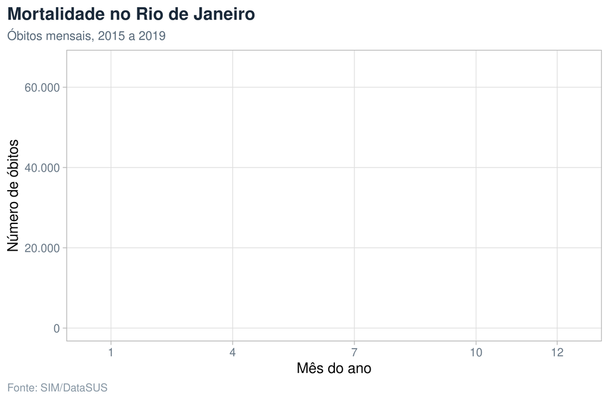

- Título — a mensagem em até 8 palavras
- Subtítulo — recorte, período, amostra
- Eixos — o que é medido e em que unidade
- Fonte — de onde vieram os dados

## Componentes dinâmicos: as camadas

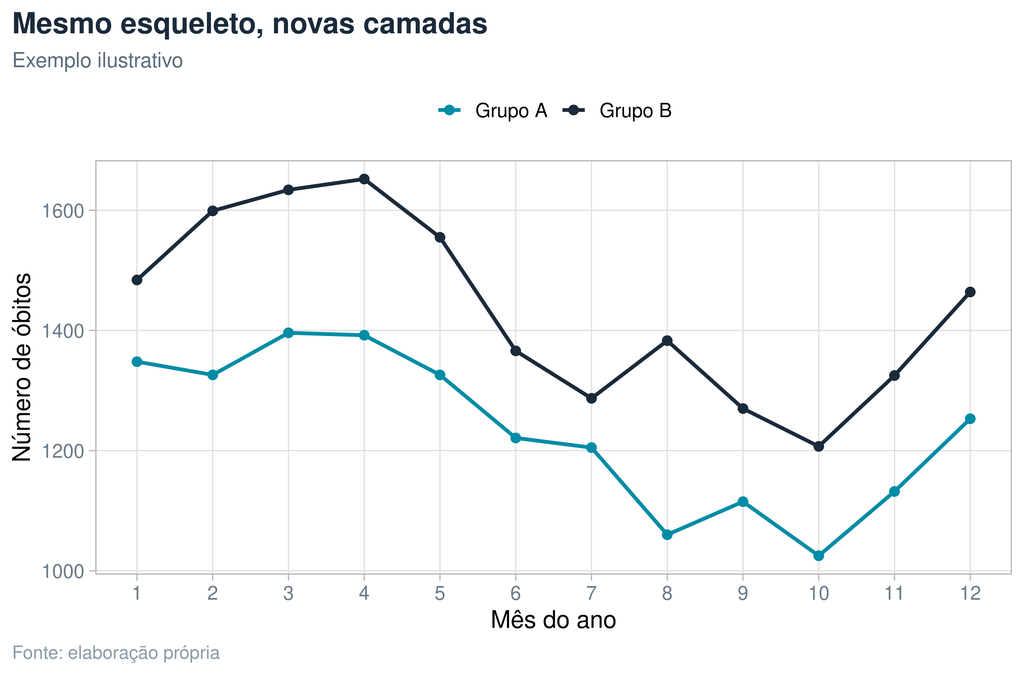

- Linhas
- Formas
- Cores
- Tamanhos
- Textos dentro do gráfico

O que muda com os dados: as camadas.  
O que não muda: o esqueleto.

## Qual canal para qual dado

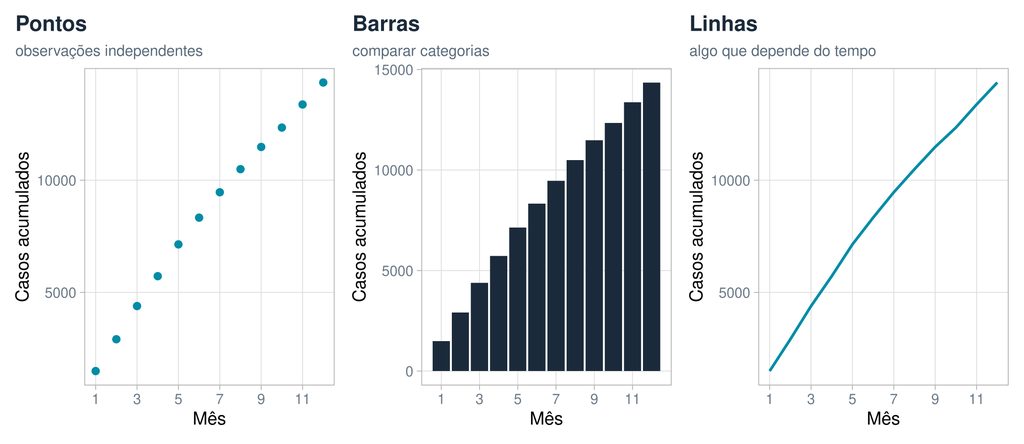

Os mesmos dados, três canais. Linhas quando há dependência; pontos quando cada caso é independente; barras quando a variável é categórica.

## Quando o gráfico tenta dizer tudo

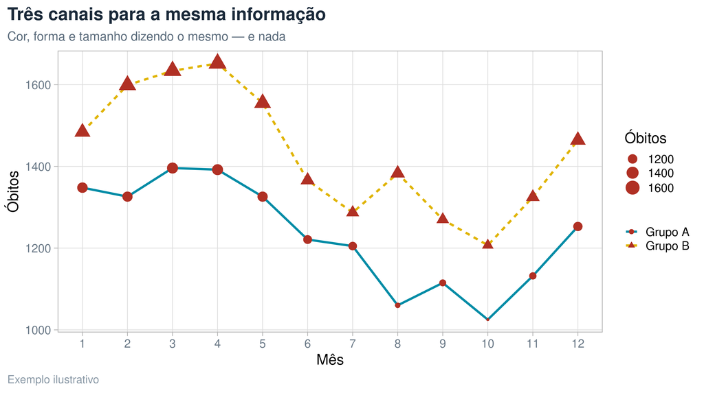

Mais canais não é mais informação. É mais tempo de leitura para a mesma mensagem.

## Os dados: mortalidade no Rio de Janeiro

| Variável | Tipo |
| --- | --- |
| DTOBITO | Date |
| DTNASC | Date |
| SEXO | character |
| OCUP | character |
| munResNome | character |
| idade_obito | numeric |

689.048

registros de óbito · 6 variáveis · 2015 a 2019

Cada linha é um óbito — formato longo. É assim que o ggplot2 espera receber os dados.

**Formato longo** — uma linha por observação. É o que o `ggplot2` consome.

**Formato largo** — uma coluna por mês. Precisa ser convertido antes de plotar.

## Pergunta 1: quando morrem as pessoas?

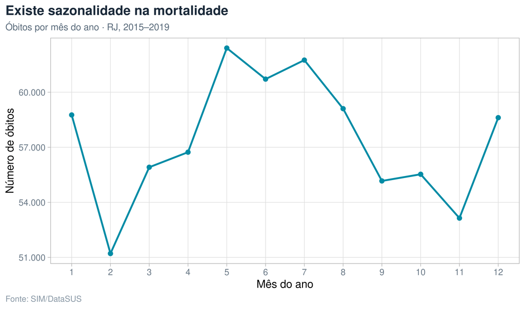

Maio, junho e julho concentram mais óbitos. Fevereiro — o mês mais curto — fica bem abaixo da média.

## Pergunta 1: direcionando a atenção

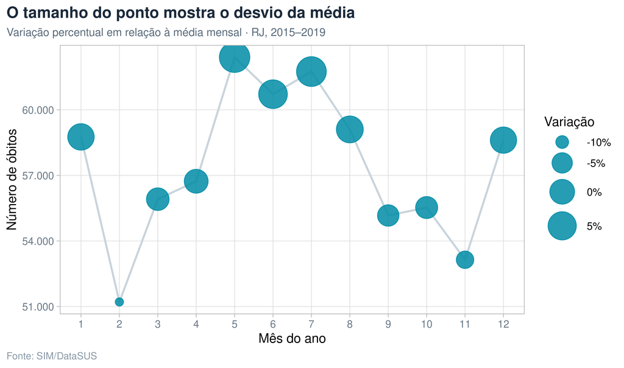

## Pergunta 2: a distribuição é igual entre os sexos?

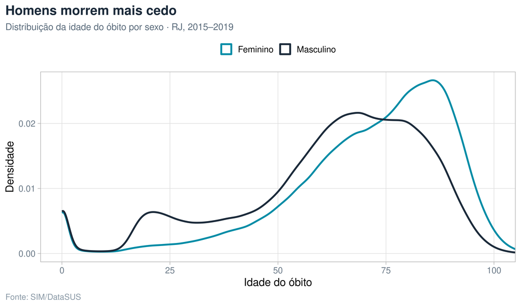

## Pergunta 2: a mesma mensagem em quartis

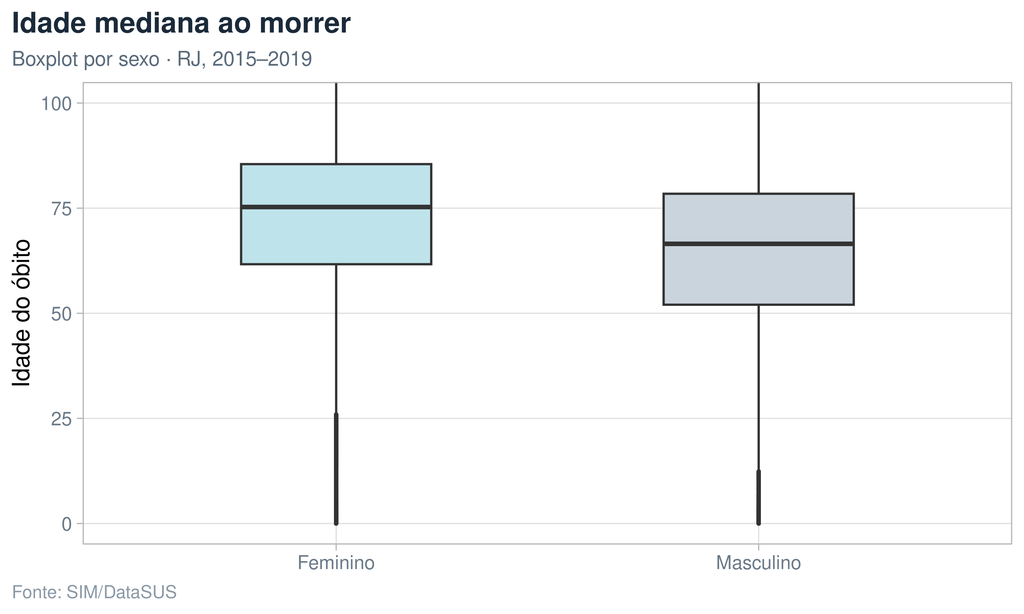

## Pergunta 3: o padrão se repete nos dois grupos?

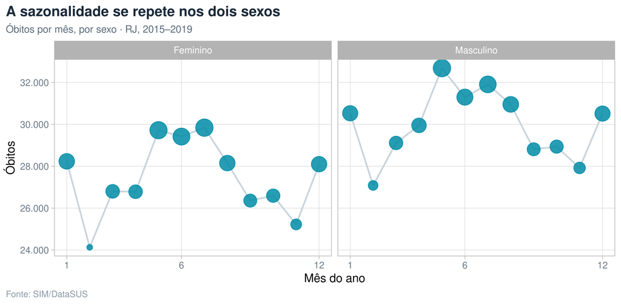

## Três gráficos, três decisões

QUANDO Alocar recursos no ano?  
Picos em maio, junho e julho

PARA QUEM Priorizar prevenção?  
Homens morrem 9 anos mais cedo

ONDE Agir primeiro?  
Recorte por município ou regional

Cada figura responde a uma pergunta. Se você não sabe qual, volte ao princípio nº 1 — e considere retirá-la.

## A lógica do ggplot2

[figure not shown]

```r
ggplot(data = df_mes, aes(x = mes, y = n)) +
  geom_line() +
  geom_point() +
  labs(
    title    = "Existe sazonalidade na mortalidade",
    subtitle = "Óbitos por mês do ano · RJ, 2015–2019",
    x = "Mês do ano",
    y = "Número de óbitos",
    caption  = "Fonte: SIM/DataSUS"
  ) +
  theme_light()
```

ggplot()cria a tela vazia — o esqueleto

aes()mapeia colunas em canais

+adiciona camadas

labs()dá nome a tudo

## Cinco perguntas antes de publicar

1. Qual pergunta este gráfico responde?
2. O título diz o quê, onde e quando?
3. O subtítulo traz o recorte e a amostra?
4. Os canais visuais são os mais intuitivos para esse dado?
5. A fonte está indicada e o arquivo tem nome padronizado?

Cinco "sim" — o gráfico está pronto para sair do seu computador.

## O que fica

- A razão da análise é a comunicação.  
  Relatório que ninguém entende tem impacto zero.
- Uma figura precisa justificar a sua existência.  
  Quatro princípios, menos gráficos, mais força.
- A ferramenta é acessível.  
  DataSUS + ggplot2 + três camadas de código.

### Para continuar

**ggplot2-book.org**  
Wickham, *ggplot2: Elegant Graphics for Data Analysis*  
**dados.gov.br**  
Portal Brasileiro de Dados Abertos  
**datasus.saude.gov.br**  
Bases do SUS · pacote `microdatasus`

## Qual gráfico você vai refazer esta semana?

Escolha um gráfico.  
**Um só.**

É assim que a cultura de avaliação sai do papel.